# Practical Machine Learning. Course Project. Prediction Assignment Writeup

Anastasiia Alieksieienko

7/9/2018

## Overview

In this project, the goal is to use data from accelerometers on the belt, forearm, arm, and dumbell of 6 participants to predict the manner in which they did the exercise.

## Loading and Preprocessing the Data

The following code loads csv files with training and testing data to the current working directory and then reads them in.

```r
trainUrl<-"https://d396qusza40orc.cloudfront.net/predmachlearn/pml-training.csv"
testUrl<-"https://d396qusza40orc.cloudfront.net/predmachlearn/pml-testing.csv"
download.file(trainUrl,destfile=paste0(getwd(),"/pml-training.csv"), method = "curl")
download.file(testUrl,destfile=paste0(getwd(),"/pml-testing.csv"), method = "curl")
pmlTrain<-read.csv("pml-training.csv", stringsAsFactors = FALSE, na.strings=c("NA", "", "#DIV/0!"))
pmlTest<-read.csv("pml-testing.csv", stringsAsFactors = FALSE, na.strings=c("NA", "", "#DIV/0!"))
```

The training data set contains of 19622 observations on 160 variables. There are a lot of columns containing mostly NAs or “” in the training data set, so I’ve removed them both from training and testing data sets. I’ve also excluded variables 1:7 that are not relevant for predicting the way the excercise was done.

```r
library(dplyr)
# Removing columns with NA values
csum<-colSums(is.na(pmlTrain))
nanames<-names(csum[csum>19000])
pmlTrain2<-select(pmlTrain, -c(nanames))
pmlTesting<-select(pmlTest, -c(nanames))
# Removing irrelevant columns
pmlTrain2<-pmlTrain2[,-(1:7)]
pmlTesting<-pmlTesting[,-(1:7)]
```

Next step is to check the remaining columns for zero/near-zero values and remove those if there are any.

```r
library(caret)
nzval<-nearZeroVar(pmlTrain2, saveMetrics = TRUE)
nzval
```

As we can see - all are false, so there is nothing to remove.

[output not shown]

After the procedure the number of variables decreased to 53. Since there are a lot of observations in training set we can split it in two subsets: training (75%) and validation (25%) in order to find out what model is better before applying it to the test set.

```r
pmlTrain2$classe<-as.factor(pmlTrain2$classe)
```

```r
library(caret)
set.seed(123456)
inTrain<-createDataPartition(y=pmlTrain2$classe, p=0.75, list = FALSE)
pmlValidation<-pmlTrain2[-inTrain,]
pmlTraining<-pmlTrain2[inTrain,]
```

## Fitting models

Since many models utilize random numbers during the phase where parameters are estimated and to ensure that the same resamples are used between calls to train we’ll use *set.seed* prior to every call to *train* function. We will fit 6 models:

- Linear Discriminant Analysis - lda2
- Random Forest - rf
- Generalized Boosted Regression Model - gbm
- Support Vector Machines - svm
- Two types of K-Nearest Neighbours (regular and weighted) - knn, kknn

### Linear Discriminant Analysis

```r
set.seed(123456)
fitlda2<-train(classe~., data=pmlTraining, method="lda2", preProcess="knnImpute",
              trControl=trainControl(method="cv", number=3))
fitlda2
```

```
Linear Discriminant Analysis

14718 samples
   52 predictor
    5 classes: 'A', 'B', 'C', 'D', 'E'

Pre-processing: nearest neighbor imputation (52), centered (52),
 scaled (52)
Resampling: Cross-Validated (3 fold)
Summary of sample sizes: 9812, 9811, 9813
Resampling results across tuning parameters:

  dimen  Accuracy   Kappa
  1      0.4697651  0.3166359
  2      0.5950536  0.4862335
  3      0.6449928  0.5497851
  4      0.7008431  0.6213326

Accuracy was used to select the optimal model using the largest value.
The final value used for the model was dimen = 4.
```

```r
vPredict<-predict(fitlda2, pmlValidation)
cmlda2<-confusionMatrix(pmlValidation$classe,vPredict); cmlda2
```

```
Confusion Matrix and Statistics

          Reference
Prediction    A    B    C    D    E
         A 1153   34  108   97    3
         B  152  604  113   35   45
         C   76   74  560  114   31
         D   46   37  100  602   19
         E   43  157   80  108  513

Overall Statistics

               Accuracy : 0.6998
                 95% CI : (0.6868, 0.7126)
    No Information Rate : 0.2998
    P-Value [Acc > NIR] : < 2.2e-16

                  Kappa : 0.62
 Mcnemar's Test P-Value : < 2.2e-16

Statistics by Class:

                     Class: A Class: B Class: C Class: D Class: E
Sensitivity            0.7844   0.6667   0.5827   0.6297   0.8396
Specificity            0.9295   0.9137   0.9252   0.9488   0.9096
Pos Pred Value         0.8265   0.6365   0.6550   0.7488   0.5694
Neg Pred Value         0.9097   0.9236   0.9010   0.9137   0.9755
Prevalence             0.2998   0.1847   0.1960   0.1949   0.1246
Detection Rate         0.2351   0.1232   0.1142   0.1228   0.1046
Detection Prevalence   0.2845   0.1935   0.1743   0.1639   0.1837
Balanced Accuracy      0.8569   0.7902   0.7540   0.7893   0.8746
```

### Random Forests

```r
set.seed(123456)
fitrf<-train(classe~., data=pmlTraining, method="rf", preProcess="knnImpute",
             trControl=trainControl(method="cv", number=3))
fitrf
```

```
Random Forest

14718 samples
   52 predictor
    5 classes: 'A', 'B', 'C', 'D', 'E'

Pre-processing: nearest neighbor imputation (52), centered (52),
 scaled (52)
Resampling: Cross-Validated (3 fold)
Summary of sample sizes: 9812, 9811, 9813
Resampling results across tuning parameters:

  mtry  Accuracy   Kappa
   2    0.9883135  0.9852154
  27    0.9896042  0.9868490
  52    0.9803634  0.9751556

Accuracy was used to select the optimal model using the largest value.
The final value used for the model was mtry = 27.
```

```r
vPredict<-predict(fitrf, pmlValidation)
cmrf<-confusionMatrix(pmlValidation$classe,vPredict); cmrf
```

```
Confusion Matrix and Statistics

          Reference
Prediction    A    B    C    D    E
         A 1395    0    0    0    0
         B    4  943    2    0    0
         C    0    3  849    3    0
         D    0    0    7  797    0
         E    0    1    4    3  893

Overall Statistics

               Accuracy : 0.9945
                 95% CI : (0.992, 0.9964)
    No Information Rate : 0.2853
    P-Value [Acc > NIR] : < 2.2e-16

                  Kappa : 0.993
 Mcnemar's Test P-Value : NA

Statistics by Class:

                     Class: A Class: B Class: C Class: D Class: E
Sensitivity            0.9971   0.9958   0.9849   0.9925   1.0000
Specificity            1.0000   0.9985   0.9985   0.9983   0.9980
Pos Pred Value         1.0000   0.9937   0.9930   0.9913   0.9911
Neg Pred Value         0.9989   0.9990   0.9968   0.9985   1.0000
Prevalence             0.2853   0.1931   0.1758   0.1637   0.1821
Detection Rate         0.2845   0.1923   0.1731   0.1625   0.1821
Detection Prevalence   0.2845   0.1935   0.1743   0.1639   0.1837
Balanced Accuracy      0.9986   0.9971   0.9917   0.9954   0.9990
```

### Generalized Boosted Regression Model

```r
set.seed(123456)
fitgbm<-train(classe~., data=pmlTraining, method="gbm", preProcess="knnImpute",
              trControl=trainControl(method="cv", number=3), verbose=FALSE)
fitgbm
```

```
Stochastic Gradient Boosting

14718 samples
   52 predictor
    5 classes: 'A', 'B', 'C', 'D', 'E'

Pre-processing: nearest neighbor imputation (52), centered (52),
 scaled (52)
Resampling: Cross-Validated (3 fold)
Summary of sample sizes: 9812, 9811, 9813
Resampling results across tuning parameters:

  interaction.depth  n.trees  Accuracy   Kappa
  1                   50      0.7506455  0.6839001
  1                  100      0.8204911  0.7727524
  1                  150      0.8526968  0.8135909
  2                   50      0.8576571  0.8196083
  2                  100      0.9087509  0.8844991
  2                  150      0.9334823  0.9158221
  3                   50      0.8938040  0.8655349
  3                  100      0.9427908  0.9275977
  3                  150      0.9590973  0.9482429

Tuning parameter 'shrinkage' was held constant at a value of 0.1

Tuning parameter 'n.minobsinnode' was held constant at a value of 10
Accuracy was used to select the optimal model using the largest value.
The final values used for the model were n.trees = 150,
 interaction.depth = 3, shrinkage = 0.1 and n.minobsinnode = 10.
```

```r
vPredict<-predict(fitgbm, pmlValidation)
cmgbm<-confusionMatrix(pmlValidation$classe,vPredict); cmgbm
```

```
Confusion Matrix and Statistics

          Reference
Prediction    A    B    C    D    E
         A 1366   15    9    4    1
         B   26  897   25    0    1
         C    0   26  818    8    3
         D    1    2   30  767    4
         E    1    4   19   15  862

Overall Statistics

               Accuracy : 0.9604
                 95% CI : (0.9546, 0.9657)
    No Information Rate : 0.2843
    P-Value [Acc > NIR] : < 2.2e-16

                  Kappa : 0.95
 Mcnemar's Test P-Value : 5.442e-07

Statistics by Class:

                     Class: A Class: B Class: C Class: D Class: E
Sensitivity            0.9799   0.9502   0.9079   0.9660   0.9897
Specificity            0.9917   0.9869   0.9908   0.9910   0.9903
Pos Pred Value         0.9792   0.9452   0.9567   0.9540   0.9567
Neg Pred Value         0.9920   0.9881   0.9795   0.9934   0.9978
Prevalence             0.2843   0.1925   0.1837   0.1619   0.1776
Detection Rate         0.2785   0.1829   0.1668   0.1564   0.1758
Detection Prevalence   0.2845   0.1935   0.1743   0.1639   0.1837
Balanced Accuracy      0.9858   0.9685   0.9493   0.9785   0.9900
```

### Support Vector Machines

SVM is one of the most widely-used and robust classifiers. Not only can it efficiently classify linear decision boundaries, but it can also classify non-linear boundaries and solve linearly inseparable problems. As we can see it’s little less accurate than rf and gbm, but much more precise than lda.

```r
library(e1071)
set.seed(123456)
fitsvm<-svm(classe~., data=pmlTraining)
fitsvm
```

```
Call:
svm(formula = classe ~ ., data = pmlTraining)


Parameters:
   SVM-Type:  C-classification
 SVM-Kernel:  radial
       cost:  1
      gamma:  0.01923077

Number of Support Vectors:  6760
```

```r
vPredict<-predict(fitsvm, pmlValidation)
cmsvm<-confusionMatrix(pmlValidation$classe,vPredict); cmsvm
```

```
Confusion Matrix and Statistics

          Reference
Prediction    A    B    C    D    E
         A 1382    4    9    0    0
         B   59  862   27    0    1
         C    2   31  812    9    1
         D    2    0   82  719    1
         E    1    7   28   21  844

Overall Statistics

               Accuracy : 0.9419
                 95% CI : (0.935, 0.9483)
    No Information Rate : 0.2949
    P-Value [Acc > NIR] : < 2.2e-16

                  Kappa : 0.9264
 Mcnemar's Test P-Value : NA

Statistics by Class:

                     Class: A Class: B Class: C Class: D Class: E
Sensitivity            0.9557   0.9535   0.8476   0.9599   0.9965
Specificity            0.9962   0.9782   0.9891   0.9795   0.9860
Pos Pred Value         0.9907   0.9083   0.9497   0.8943   0.9367
Neg Pred Value         0.9818   0.9894   0.9639   0.9927   0.9993
Prevalence             0.2949   0.1843   0.1954   0.1527   0.1727
Detection Rate         0.2818   0.1758   0.1656   0.1466   0.1721
Detection Prevalence   0.2845   0.1935   0.1743   0.1639   0.1837
Balanced Accuracy      0.9760   0.9659   0.9184   0.9697   0.9912
```

### K-Nearest Neighbor Classifier

```r
set.seed(123456)
fitknn<-train(classe~., data=pmlTraining, method="knn", preProcess="knnImpute",
              trControl=trainControl(method="cv", number=3))
fitknn
```

```
k-Nearest Neighbors

14718 samples
   52 predictor
    5 classes: 'A', 'B', 'C', 'D', 'E'

Pre-processing: nearest neighbor imputation (52), centered (52),
 scaled (52)
Resampling: Cross-Validated (3 fold)
Summary of sample sizes: 9812, 9811, 9813
Resampling results across tuning parameters:

  k  Accuracy   Kappa
  5  0.9474790  0.9335486
  7  0.9313758  0.9131477
  9  0.9173792  0.8954277

Accuracy was used to select the optimal model using the largest value.
The final value used for the model was k = 5.
```

```r
vPredict<-predict(fitknn, pmlValidation)
cmknn<-confusionMatrix(pmlValidation$classe,vPredict); cmknn
```

```
Confusion Matrix and Statistics

          Reference
Prediction    A    B    C    D    E
         A 1382    5    7    0    1
         B   22  912   15    0    0
         C    4   16  825   10    0
         D    3    0   32  767    2
         E    0   12   16    6  867

Overall Statistics

               Accuracy : 0.9692
                 95% CI : (0.964, 0.9739)
    No Information Rate : 0.2877
    P-Value [Acc > NIR] : < 2.2e-16

                  Kappa : 0.961
 Mcnemar's Test P-Value : NA

Statistics by Class:

                     Class: A Class: B Class: C Class: D Class: E
Sensitivity            0.9794   0.9651   0.9218   0.9796   0.9966
Specificity            0.9963   0.9907   0.9925   0.9910   0.9916
Pos Pred Value         0.9907   0.9610   0.9649   0.9540   0.9623
Neg Pred Value         0.9917   0.9917   0.9827   0.9961   0.9993
Prevalence             0.2877   0.1927   0.1825   0.1597   0.1774
Detection Rate         0.2818   0.1860   0.1682   0.1564   0.1768
Detection Prevalence   0.2845   0.1935   0.1743   0.1639   0.1837
Balanced Accuracy      0.9879   0.9779   0.9572   0.9853   0.9941
```

### Weighted k-Nearest Neighbor Classifier

Performs k-nearest neighbor classification: for each row of the test set, the k nearest training set vectors (according to Minkowski distance) are found, and the classification is done via the maximum of summed kernel densities.

```r
library(kknn)
set.seed(123456)
fitkknn<-train(classe~., data=pmlTraining, method="kknn", preProcess="knnImpute",
              trControl=trainControl(method="cv", number=3))
fitkknn
```

```
k-Nearest Neighbors

14718 samples
   52 predictor
    5 classes: 'A', 'B', 'C', 'D', 'E'

Pre-processing: nearest neighbor imputation (52), centered (52),
 scaled (52)
Resampling: Cross-Validated (3 fold)
Summary of sample sizes: 9812, 9811, 9813
Resampling results across tuning parameters:

  kmax  Accuracy   Kappa
  5     0.9824025  0.9777427
  7     0.9824025  0.9777427
  9     0.9824025  0.9777427

Tuning parameter 'distance' was held constant at a value of 2

Tuning parameter 'kernel' was held constant at a value of optimal
Accuracy was used to select the optimal model using the largest value.
The final values used for the model were kmax = 9, distance = 2 and
 kernel = optimal.
```

```r
vPredict<-predict(fitkknn, pmlValidation)
cmkknn<-confusionMatrix(pmlValidation$classe,vPredict); cmkknn
```

```
Confusion Matrix and Statistics

          Reference
Prediction    A    B    C    D    E
         A 1391    1    1    1    1
         B    5  939    4    1    0
         C    3    8  840    4    0
         D    1    1   12  788    2
         E    0    3    1    3  894

Overall Statistics

               Accuracy : 0.9894
                 95% CI : (0.9861, 0.9921)
    No Information Rate : 0.2855
    P-Value [Acc > NIR] : <2e-16

                  Kappa : 0.9866
 Mcnemar's Test P-Value : 0.1641

Statistics by Class:

                     Class: A Class: B Class: C Class: D Class: E
Sensitivity            0.9936   0.9863   0.9790   0.9887   0.9967
Specificity            0.9989   0.9975   0.9963   0.9961   0.9983
Pos Pred Value         0.9971   0.9895   0.9825   0.9801   0.9922
Neg Pred Value         0.9974   0.9967   0.9956   0.9978   0.9993
Prevalence             0.2855   0.1941   0.1750   0.1625   0.1829
Detection Rate         0.2836   0.1915   0.1713   0.1607   0.1823
Detection Prevalence   0.2845   0.1935   0.1743   0.1639   0.1837
Balanced Accuracy      0.9962   0.9919   0.9877   0.9924   0.9975
```

### Plots of final models

Meaningful plots can be built for 2 models only. For random forest we can see that error decreases with increaing of the number of trees built. Plot for kknn model gives us information about the quality of the classification based on the number of neighbors.

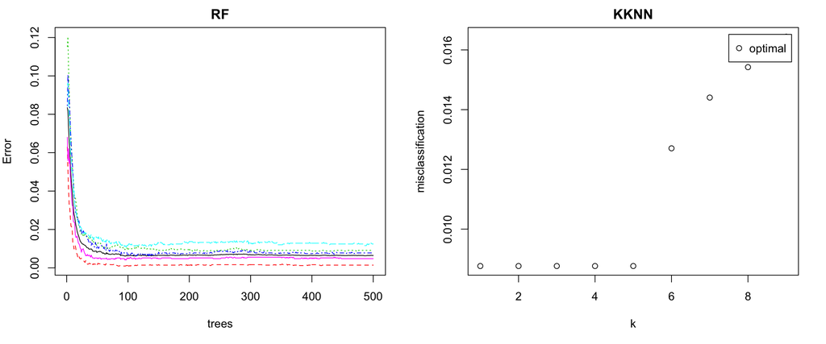

```r
par(mfrow=c(1,2),mar=c(5,4,2,2))
plot(fitrf$finalModel, main="RF")
plot(fitkknn$finalModel, main="KKNN")
```

### Plots for tuning parameters

The following plots show how the accuracy changes while the parameters of the models are tuned. The model parameters are selected based on the accuracy value.

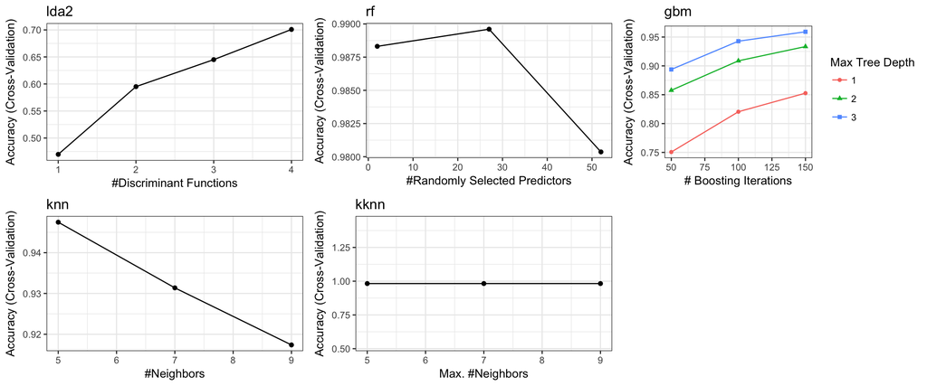

```r
p1<-ggplot(fitlda2) + labs(title="lda2") + theme_bw()
p2<-ggplot(fitrf) + labs(title="rf") + theme_bw()
p3<-ggplot(fitgbm) + labs(title="gbm") + theme_bw()
p4<-ggplot(fitknn) + labs(title="knn") + theme_bw()
p5<-ggplot(fitkknn) + labs(title="kknn") + theme_bw()
multiplot(p1, p4, p2, p5, p3, cols=3)
```

### Accuracy comparison

Random forest and KKNN model have the best accuracy, but RF is even more precise, so I’ll choose it for predicting for the test data set.

```r
accuracyDF<-data.frame(Model=c("lda2", "rf", "gbm", "svm","knn", "kknn"),
                       Accuracy=c(cmlda2$overall[1], cmrf$overall[1], cmgbm$overall[1],
                                  cmsvm$overall[1], cmknn$overall[1], cmkknn$overall[1]))
accuracyDF
```

```
  Model  Accuracy
1  lda2 0.6998369
2    rf 0.9944943
3   gbm 0.9604405
4   svm 0.9418842
5   knn 0.9692088
6  kknn 0.9893964
```

## Predicting for Test Data

Let’s predict the style of doing exercises for the test data set using trained Random Forest model with Cross Validation.

```r
testPredict<-predict(fitrf, pmlTesting)
testPredict
```

```
 [1] B A B A A E D B A A B C B A E E A B B B
Levels: A B C D E
```

## Conclusion

#### Random forest model gives the highest accuracy - 0.9944943 - on the validation data, so it was used to predict the outcomes for the test data set.